# Flight Delays Prediction / Analytics

#### Almost perfect normal distribution

```r
# Correlation
a<-cor(traintripsdep$DepDelay,
       traintripsdep$pred.DepDelay )
b<-cor(validtrips$DepDelay,
       validtrips$predict.DepDelay )
a
```

```
## [1] 1
```

```r
b
```

```
## [1] 1
```

```r
a*a
```

```
## [1] 1
```

```r
b*b
```

```
## [1] 0.9999999
```

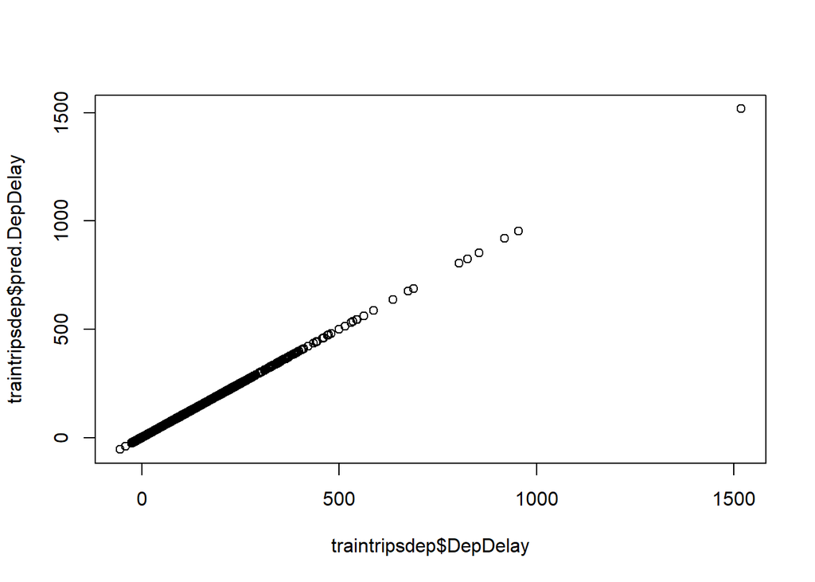

```r
plot(traintripsdep$DepDelay,
     traintripsdep$pred.DepDelay )
```

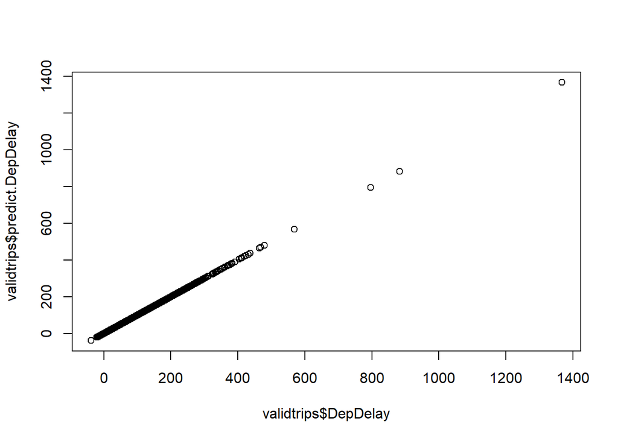

```r
plot(validtrips$DepDelay,
     validtrips$predict.DepDelay )
```

#### If we look at the Actual vs Predicted it almost follows stright line over diaognal

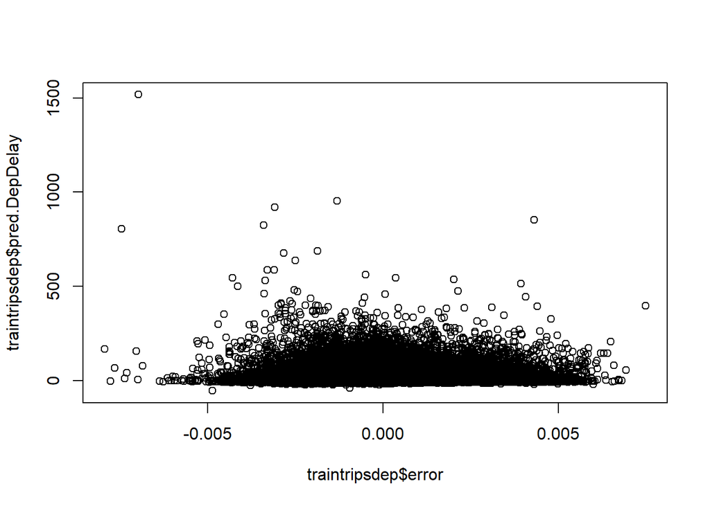

```r
plot(traintripsdep$error,
     traintripsdep$pred.DepDelay )
```

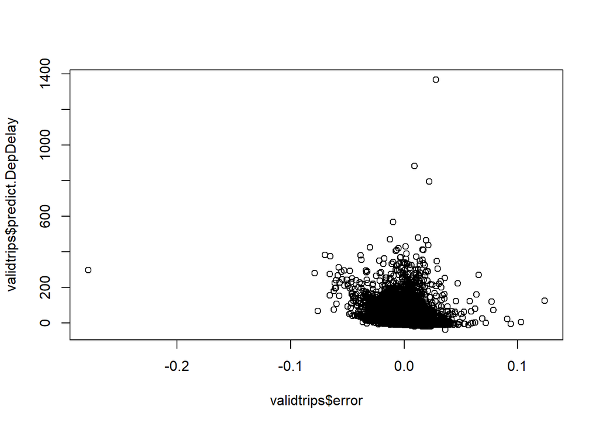

```r
plot(validtrips$error,
     validtrips$predict.DepDelay )
```

#### Model performance is good and accuracy is good as well.

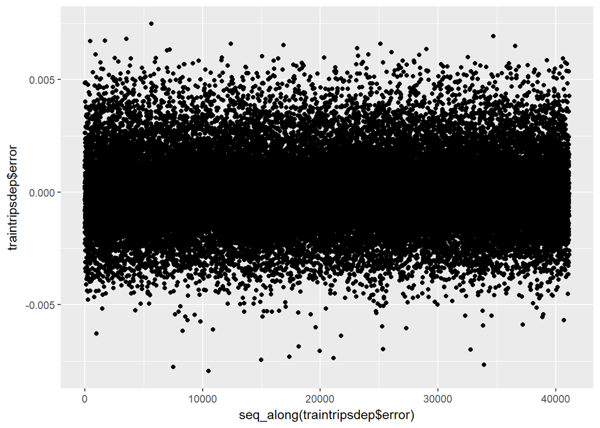

```r
qplot(y=traintripsdep$error)
```

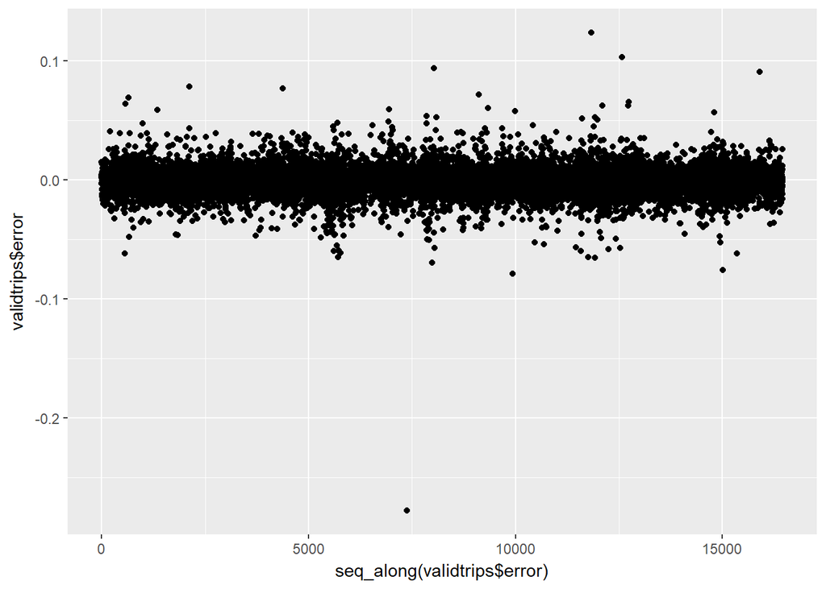

```r
qplot(y=validtrips$error)
```

Though we have tested each and every independent variable and max combinations before choosing final model. We have used alternate methods to choose variables. One of such methods is AIC. This takes combinations of variables and computes statistics. We have run STEP AIC and even with the first model seems to be best. Not showing STEPAIC here to save some real estate. In the actual code file we have it.

#### Finally we can see that out first model is better.

#### Even if we get better model by tweeking the variables. It may not do well on completely new data.

#### Let’s verify both the models on test data set and conclude at the end.

### Now it’s time to predict ArrDelay as well. We can use DespDelay as well for predicting Arrival Delay.

Here, we can assume that DepDelay information is available and predict!. There is strong co-relation between two. This will be a very good predictor. Also, later we will make DepDelay not available and predict.

```r
traintripsArr <- traintrips
#traintripsArr <- traintrips[, !grepl("DepDelay" , names(traintrips))]  # Removing Arrvilal related variables.

lm.arr.fit1 <- stats::lm(ArrDelay ~ . , data=traintripsArr)

summary(lm.arr.fit1)
```

```
##
## Call:
## stats::lm(formula = ArrDelay ~ ., data = traintripsArr)
##
## Residuals:
##     Min      1Q  Median      3Q     Max
## -54.607  -3.641   0.647   4.371  66.211
##
## Coefficients: (8 not defined because of singularities)
##                             Estimate Std. Error t value Pr(>|t|)
## (Intercept)                12.060843   1.350285   8.932  < 2e-16 ***
## `as.factor(Month)2`         0.642031   0.188208   3.411 0.000647 ***
## `as.factor(Month)3`         0.174946   0.179485   0.975 0.329710
## `as.factor(Month)4`         0.140825   0.184104   0.765 0.444323
## `as.factor(Month)5`        -0.296730   0.181343  -1.636 0.101787
## `as.factor(Month)6`         0.452582   0.179336   2.524 0.011618 *
## `as.factor(Month)7`         0.065679   0.181010   0.363 0.716720
## `as.factor(Month)8`        -0.162230   0.180890  -0.897 0.369805
## `as.factor(Month)9`        -1.461785   0.186543  -7.836 4.76e-15 ***
## `as.factor(Month)10`       -0.576779   0.184942  -3.119 0.001818 **
## `as.factor(Month)11`       -1.232887   0.185240  -6.656 2.86e-11 ***
## `as.factor(Month)12`        0.381012   0.180422   2.112 0.034712 *
## `as.factor(DayOfWeek)2`    -0.157879   0.135393  -1.166 0.243590
## `as.factor(DayOfWeek)3`     0.248451   0.135249   1.837 0.066217 .
## `as.factor(DayOfWeek)4`     0.716579   0.134060   5.345 9.08e-08 ***
## `as.factor(DayOfWeek)5`     0.479930   0.133322   3.600 0.000319 ***
## `as.factor(DayOfWeek)6`    -0.719531   0.141079  -5.100 3.41e-07 ***
## `as.factor(DayOfWeek)7`     0.155463   0.135859   1.144 0.252506
## UniqueCarrierAQ            -0.232200   0.712813  -0.326 0.744613
## UniqueCarrierAS            -0.882880   0.372718  -2.369 0.017852 *
## UniqueCarrierB6            -2.034885   0.297158  -6.848 7.60e-12 ***
## UniqueCarrierCO            -2.365133   0.250697  -9.434  < 2e-16 ***
## UniqueCarrierDL            -0.800865   0.256835  -3.118 0.001821 **
## UniqueCarrierEV            -0.307701   0.309054  -0.996 0.319441
## UniqueCarrierF9             0.922919   0.362958   2.543 0.011001 *
## UniqueCarrierFL             1.110274   0.282885   3.925 8.69e-05 ***
## UniqueCarrierHA             1.003403   0.638178   1.572 0.115890
## UniqueCarrierMQ             0.357035   0.223094   1.600 0.109523
## UniqueCarrierNW             1.106626   0.300094   3.688 0.000227 ***
## UniqueCarrierOH            -0.159526   0.307791  -0.518 0.604258
```

[output cut: 163 more lines]

```
## `as.factor(Originstate)WI` -0.792136   0.775324  -1.022 0.306937
## `as.factor(Originstate)WV` -3.523431   1.683260  -2.093 0.036336 *
## `as.factor(Originstate)WY` -2.639303   1.303994  -2.024 0.042975 *
## TaxiOut                     4.042636   0.055215  73.216  < 2e-16 ***
## CarrierDelay               19.243598   0.103096 186.656  < 2e-16 ***
## WeatherDelay                9.032610   0.056533 159.777  < 2e-16 ***
## NASDelay                   16.521654   0.075178 219.767  < 2e-16 ***
## LateAircraftDelay          19.954418   0.106373 187.590  < 2e-16 ***
## DepDelay                    0.268635   0.003660  73.405  < 2e-16 ***
## ---
## Signif. codes:  0 '***' 0.001 '**' 0.01 '*' 0.05 '.' 0.1 ' ' 1
##
## Residual standard error: 7.382 on 40948 degrees of freedom
## Multiple R-squared:  0.9755, Adjusted R-squared:  0.9754
## F-statistic:  8439 on 193 and 40948 DF,  p-value: < 2.2e-16
```

#### R-Squared: 97 and Residual error: 7

```
## [1] 7.594126
```

```
## [1] 0.7204091
```

```
## [1] 5.487433
```

### Plots For Arrival Delay

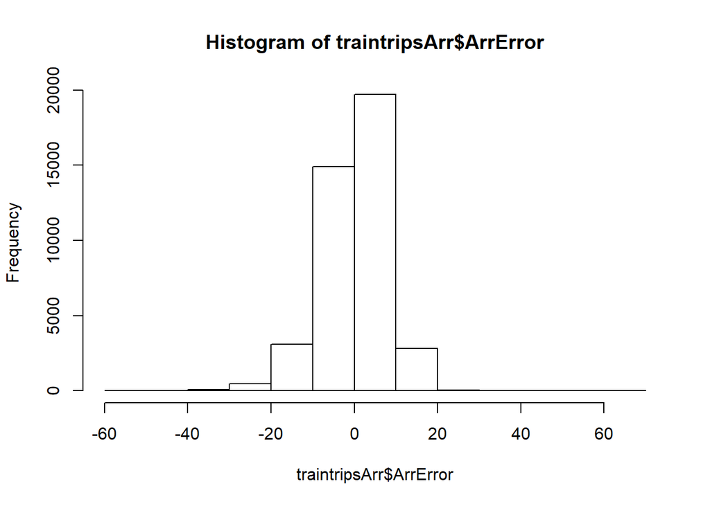

```r
# Check residual plots
hist(traintripsArr$ArrError)
```

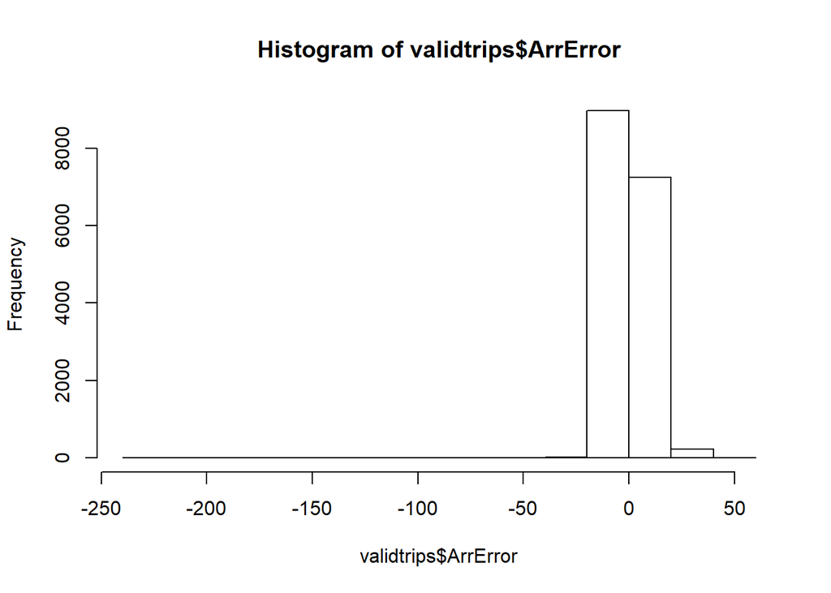

```r
hist(validtrips$ArrError)
```

In both cases the histogram is centered at zero. Espicially with Test data. This is a good test. Follows nornal distribution which is a good measure of model performance.

#### Correlation

```r
a<-cor(traintripsArr$ArrDelay,
       traintripsArr$pred.ArrDelay )
b<-cor(validtrips$ArrDelay,
       validtrips$predict.ArrDelay )
a
```

```
## [1] 0.9876618
```

```r
b
```

```
## [1] 0.9875352
```

```r
a*a
```

```
## [1] 0.9754758
```

```r
b*b
```

```
## [1] 0.9752257
```

co-relation between actul and predicted is very high satisfying the accuracy of the model.

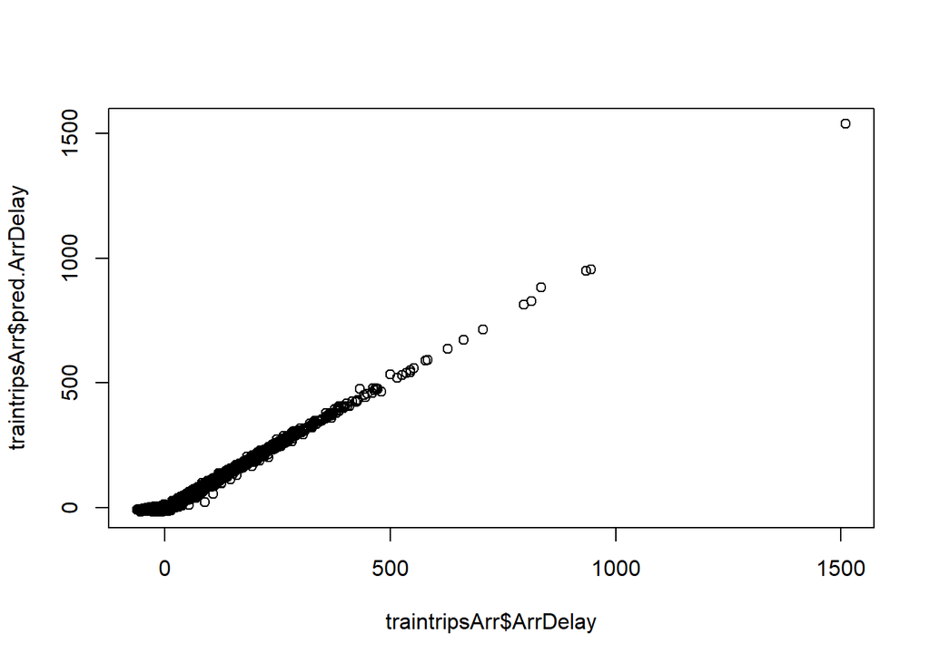

```r
plot(traintripsArr$ArrDelay,
     traintripsArr$pred.ArrDelay )
```

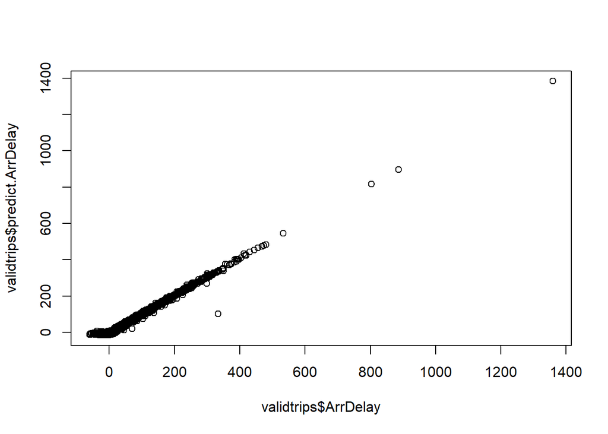

```r
plot(validtrips$ArrDelay,
     validtrips$predict.ArrDelay )
```

If we look at the Actual vs Predicted it almost follows stright line over diaognal.

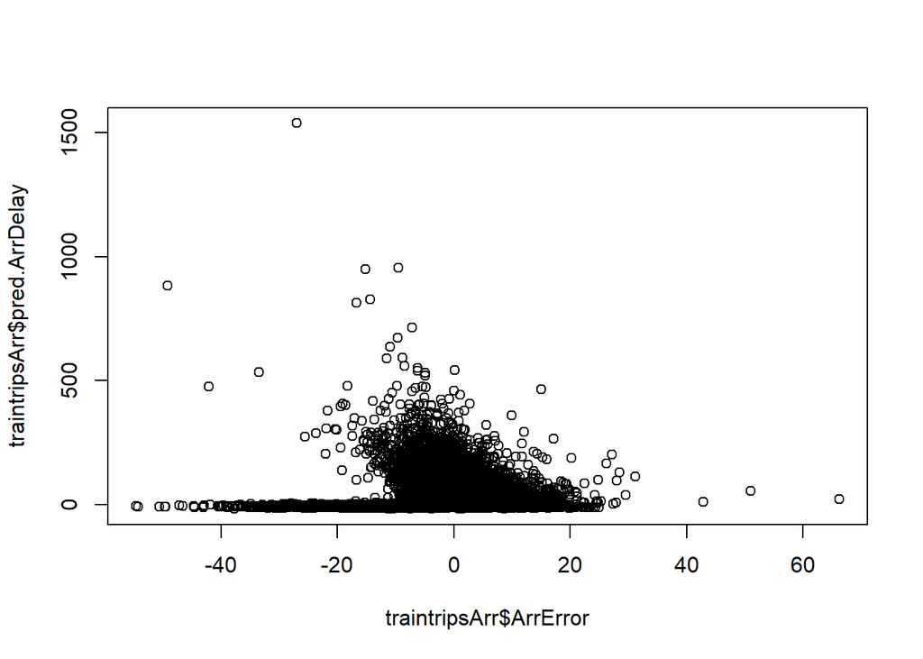

```r
plot(traintripsArr$ArrError,
     traintripsArr$pred.ArrDelay )
```

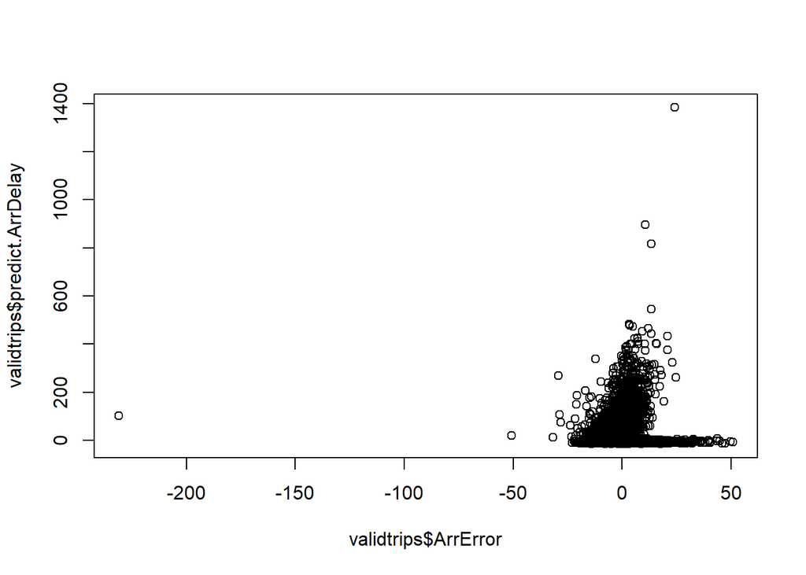

```r
plot(validtrips$ArrError,
     validtrips$predict.ArrDelay )
```

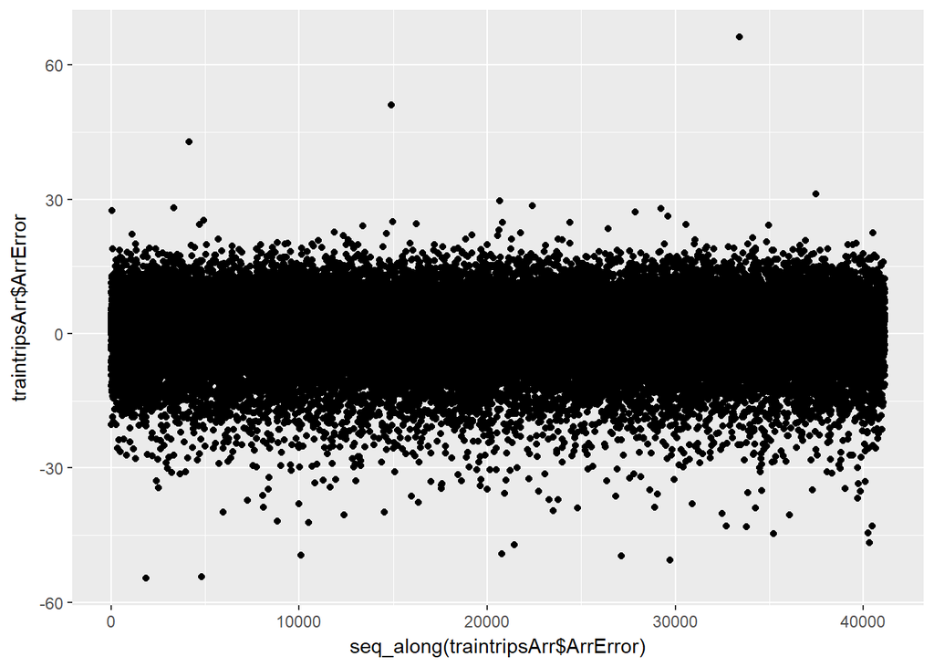

```r
qplot(y=traintripsArr$ArrError)
```

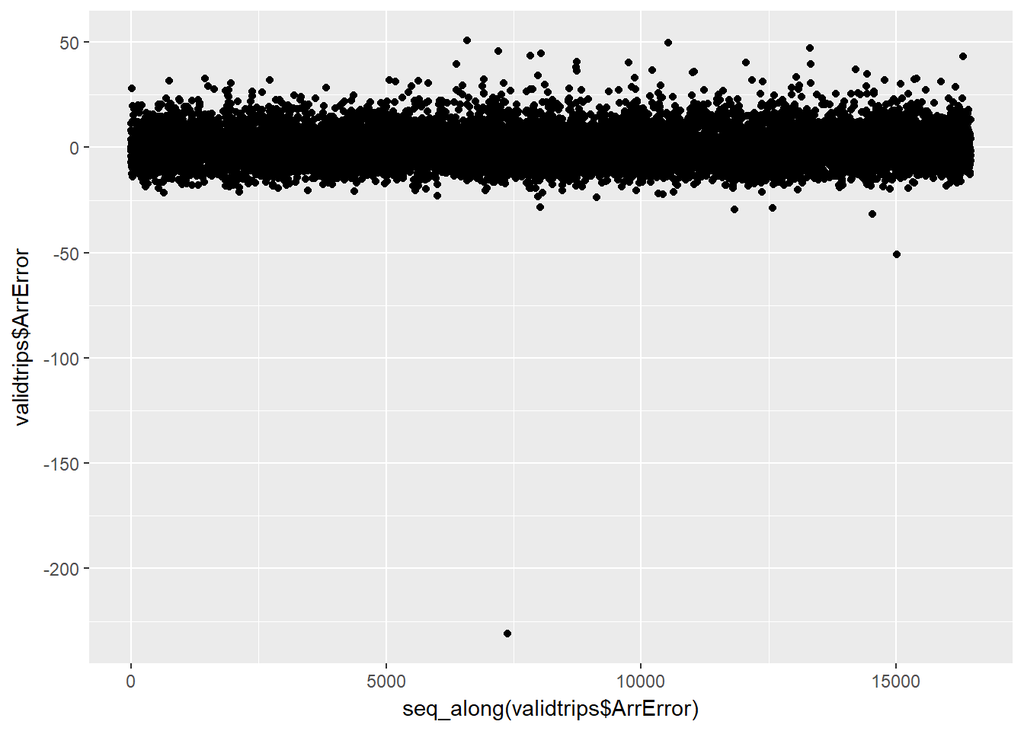

```r
qplot(y=validtrips$ArrError)
```

Follows normal distributuon. #### Model performance is good and accuracy is good as well.

#### We can try removing DepDelay (independent variable) and try and predict the ArrDelay.

Not showing all the plotsto sae some realestate. But in actual code file, we have it.

[output not shown]

[output cut: 86 more lines]

```
## [1] 203
```

```
##
## Call:
## stats::lm(formula = ArrDelay ~ ., data = traintripsArr)
##
## Residuals:
##     Min      1Q  Median      3Q     Max
## -57.627  -3.658   1.079   3.935  90.435
##
## Coefficients: (8 not defined because of singularities)
##                             Estimate Std. Error t value Pr(>|t|)
## (Intercept)                16.438311   1.434963  11.456  < 2e-16 ***
## `as.factor(Month)2`         0.783030   0.200196   3.911 9.19e-05 ***
## `as.factor(Month)3`         0.277634   0.190921   1.454 0.145903
## `as.factor(Month)4`         0.224814   0.195836   1.148 0.250987
## `as.factor(Month)5`        -0.330940   0.192903  -1.716 0.086247 .
## `as.factor(Month)6`         0.792216   0.190705   4.154 3.27e-05 ***
## `as.factor(Month)7`         0.416895   0.192482   2.166 0.030325 *
## `as.factor(Month)8`         0.202253   0.192349   1.051 0.293040
## `as.factor(Month)9`        -1.479801   0.198434  -7.457 9.00e-14 ***
## `as.factor(Month)10`       -0.513433   0.196730  -2.610 0.009062 **
## `as.factor(Month)11`       -1.143216   0.197045  -5.802 6.61e-09 ***
## `as.factor(Month)12`        0.529046   0.191912   2.757 0.005841 **
## `as.factor(DayOfWeek)2`    -0.463429   0.143956  -3.219 0.001286 **
## `as.factor(DayOfWeek)3`     0.107188   0.143856   0.745 0.456211
## `as.factor(DayOfWeek)4`     0.578318   0.142592   4.056 5.01e-05 ***
## `as.factor(DayOfWeek)5`     0.439221   0.141820   3.097 0.001956 **
## `as.factor(DayOfWeek)6`    -0.932071   0.150041  -6.212 5.28e-10 ***
## `as.factor(DayOfWeek)7`     0.042949   0.144510   0.297 0.766313
## UniqueCarrierAQ            -0.701102   0.758224  -0.925 0.355146
## UniqueCarrierAS            -0.812165   0.396477  -2.048 0.040522 *
## UniqueCarrierB6            -1.544170   0.316021  -4.886 1.03e-06 ***
## UniqueCarrierCO            -1.666075   0.266486  -6.252 4.09e-10 ***
## UniqueCarrierDL            -0.422124   0.273152  -1.545 0.122262
## UniqueCarrierEV             0.281901   0.328645   0.858 0.391026
## UniqueCarrierF9             1.046135   0.386092   2.710 0.006740 **
## UniqueCarrierFL             0.582805   0.300821   1.937 0.052706 .
## UniqueCarrierHA             0.288662   0.678782   0.425 0.670646
## UniqueCarrierMQ             0.195761   0.237305   0.825 0.409412
## UniqueCarrierNW             0.913862   0.319213   2.863 0.004200 **
## UniqueCarrierOH             0.340221   0.327332   1.039 0.298636
```

[output cut: 162 more lines]

```
## `as.factor(Originstate)WA`  0.742137   0.699622   1.061 0.288801
## `as.factor(Originstate)WI` -0.383763   0.824729  -0.465 0.641704
## `as.factor(Originstate)WV` -3.333444   1.790563  -1.862 0.062656 .
## `as.factor(Originstate)WY` -2.352818   1.387116  -1.696 0.089857 .
## TaxiOut                     1.764635   0.048580  36.324  < 2e-16 ***
## CarrierDelay               26.315954   0.039029 674.270  < 2e-16 ***
## WeatherDelay               12.238761   0.038180 320.554  < 2e-16 ***
## NASDelay                   21.074574   0.045190 466.353  < 2e-16 ***
## LateAircraftDelay          27.271039   0.039519 690.078  < 2e-16 ***
## ---
## Signif. codes:  0 '***' 0.001 '**' 0.01 '*' 0.05 '.' 0.1 ' ' 1
##
## Residual standard error: 7.853 on 40949 degrees of freedom
## Multiple R-squared:  0.9722, Adjusted R-squared:  0.9721
## F-statistic:  7472 on 192 and 40949 DF,  p-value: < 2.2e-16
```

It may predict well on Validation data set.

#### Even here model performance is good and accuracy is good as well.

#### We can use eaither of the models. If it is for predicting much earlier say week before the flight, then we don’t have DepDelay info so we can use second on. But if you are using for realtime flight delay prediction than we can use first one.

#### Finally, we need to apply this model to test data set to see the results.

### And once this is ready, we need to use the final model in function which accepts these input variables as parameters and predicts the delay.